# Reproducible Research(Project 1)

Maria David

9/19/2020

**Loading the data**

```r
#Using read.csv to read the data
activity <- read.csv("F:/online_courses/activity.csv")
```

**Understanding the Data**

```r
names(activity)
```

```
## [1] "steps"    "date"     "interval"
```

```r
head(activity)
```

```
##   steps       date interval
## 1    NA 2012-10-01        0
## 2    NA 2012-10-01        5
## 3    NA 2012-10-01       10
## 4    NA 2012-10-01       15
## 5    NA 2012-10-01       20
## 6    NA 2012-10-01       25
```

```r
str(activity)
```

```
## 'data.frame':    17568 obs. of  3 variables:
##  $ steps   : int  NA NA NA NA NA NA NA NA NA NA ...
##  $ date    : chr  "2012-10-01" "2012-10-01" "2012-10-01" "2012-10-01" ...
##  $ interval: int  0 5 10 15 20 25 30 35 40 45 ...
```

```r
dim(activity)
```

```
## [1] 17568     3
```

**What is mean total number of steps taken per day?**

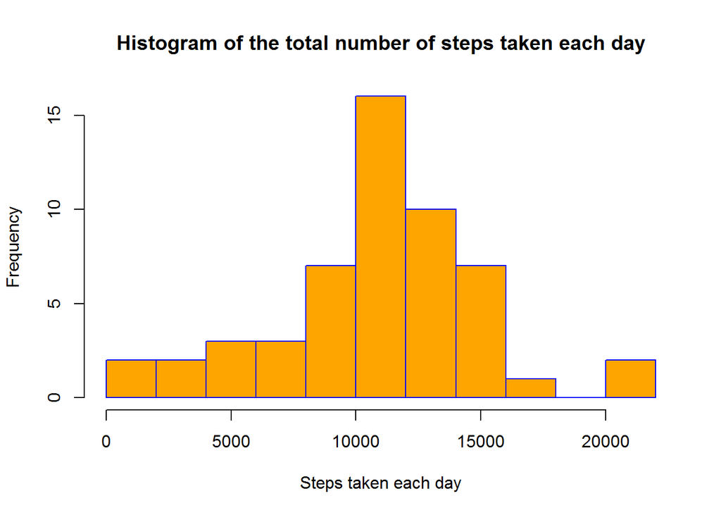

```r
#Using aggregate function to find the total no. of steps taken each day
stepseachday <- aggregate(steps ~ date, activity, sum, na.rm=TRUE)
#Histogram of the total number of steps taken each day
hist(stepseachday$steps,main="Histogram of the total number of steps taken each day",xlab = "Steps taken each day",border = "blue",col="orange",breaks=10)
```

Mean and median number of steps taken each day

```r
#mean
meanstep<-mean(stepseachday$steps)
meanstep
```

```
## [1] 10766.19
```

```r
#median
medianstep<-median(stepseachday$steps)
medianstep
```

```
## [1] 10765
```

**What is the average daily activity pattern?**

```r
#Using aggregate to average steps and interval
avgsteps <- aggregate(steps ~ interval, activity, mean, na.rm=TRUE)
head(avgsteps)
```

```
##   interval     steps
## 1        0 1.7169811
## 2        5 0.3396226
## 3       10 0.1320755
## 4       15 0.1509434
## 5       20 0.0754717
## 6       25 2.0943396
```

Time series plot of the 5-minute interval and the average number of steps taken

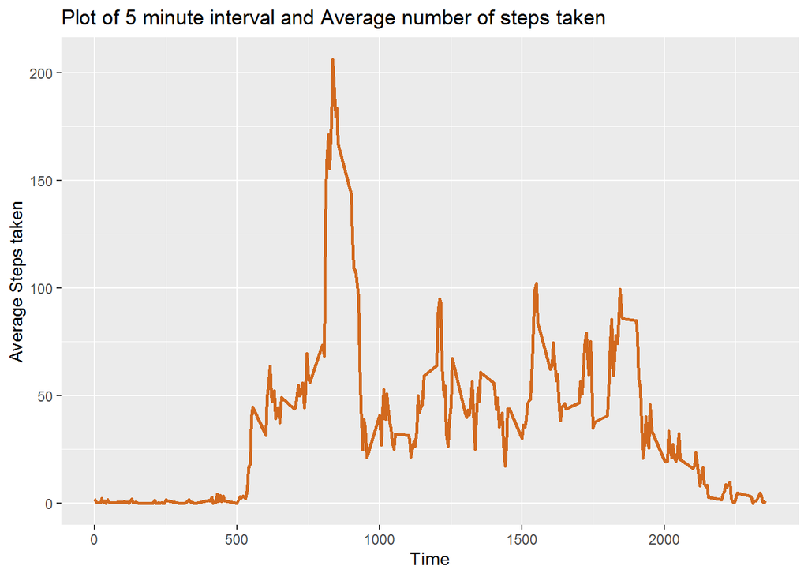

```r
library(ggplot2)
g<-ggplot(avgsteps,aes(interval,steps))
g+geom_line(col="chocolate",size=1)+
  ggtitle("Plot of 5 minute interval and Average number of steps taken")+
  xlab("Time")+
  ylab("Average Steps taken")
```

Find Which 5-minute interval, on average across all the days in the dataset, contains the maximum number of steps

```r
library(dplyr)
#Using the filter function to find which interval had max no.of steps
avgsteps%>%filter(steps==max(avgsteps$steps))
```

```
##   interval    steps
## 1      835 206.1698
```

**Imputing missing values**

Calculate and report the total number of missing values in the dataset

```r
#Using sum fuction to find the total number of missing values
sum(is.na(activity))
```

```
## [1] 2304
```

Devise a strategy for filling in all of the missing values in the dataset.

```r
#Creating a column 'filling' to store the filled values
#Here NA value's are replaced with the mean values of the intervals
activity$filling <- ifelse(is.na(activity$steps), round(avgsteps$steps[match(activity$interval, avgsteps$interval)],0), activity$steps)
```

Replace the original dataset with missing data filled.

```r
#The new dataset with filled missing value is stored in'Newactivity'
Newactivity<-data.frame(steps=activity$filling,interval=activity$interval,date=activity$date)
head(Newactivity,n=10)
```

```
##    steps interval       date
## 1      2        0 2012-10-01
## 2      0        5 2012-10-01
## 3      0       10 2012-10-01
## 4      0       15 2012-10-01
## 5      0       20 2012-10-01
## 6      2       25 2012-10-01
## 7      1       30 2012-10-01
## 8      1       35 2012-10-01
## 9      0       40 2012-10-01
## 10     1       45 2012-10-01
```

Histogram of the New dataset

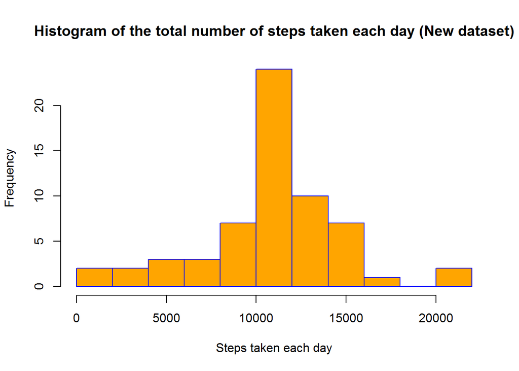

```r
#Using aggregate function to find the total no. of steps taken each day
Newstepseachday <- aggregate(steps ~ date, Newactivity, sum, na.rm=TRUE)
#Histogram of the total number of steps taken each day
hist(Newstepseachday$steps,main="Histogram of the total number of steps taken each day (New dataset)",xlab = "Steps taken each day",border = "blue",col="orange",breaks=10)
```

Mean and median number of steps taken each day(New dataset)

```r
#mean
meanstep2<-mean(Newstepseachday$steps)
meanstep2
```

```
## [1] 10765.64
```

```r
#median
medianstep2<-median(Newstepseachday$steps)
medianstep2
```

```
## [1] 10762
```

**Are there differences in activity patterns between weekdays and weekends?**

Create a new factor variable in the dataset with two levels – “weekday” and “weekend” indicating whether a given date is a weekday or weekend day.

```r
#Converting character to date format to use the function weekdays
Newactivity$date <- as.Date(Newactivity$date, format = "%Y-%m-%d")
Newactivity$weekday <- weekdays(Newactivity$date)
Newactivity$week <- ifelse(Newactivity$weekday=='Saturday' | Newactivity$weekday=='Sunday', 'weekend','weekday')
head(Newactivity)
```

```
##   steps interval       date weekday    week
## 1     2        0 2012-10-01  Monday weekday
## 2     0        5 2012-10-01  Monday weekday
## 3     0       10 2012-10-01  Monday weekday
## 4     0       15 2012-10-01  Monday weekday
## 5     0       20 2012-10-01  Monday weekday
## 6     2       25 2012-10-01  Monday weekday
```

Make a panel plot containing a time series plot of the 5-minute interval (x-axis) and the average number of steps taken, averaged across all weekday days or weekend days (y-axis).

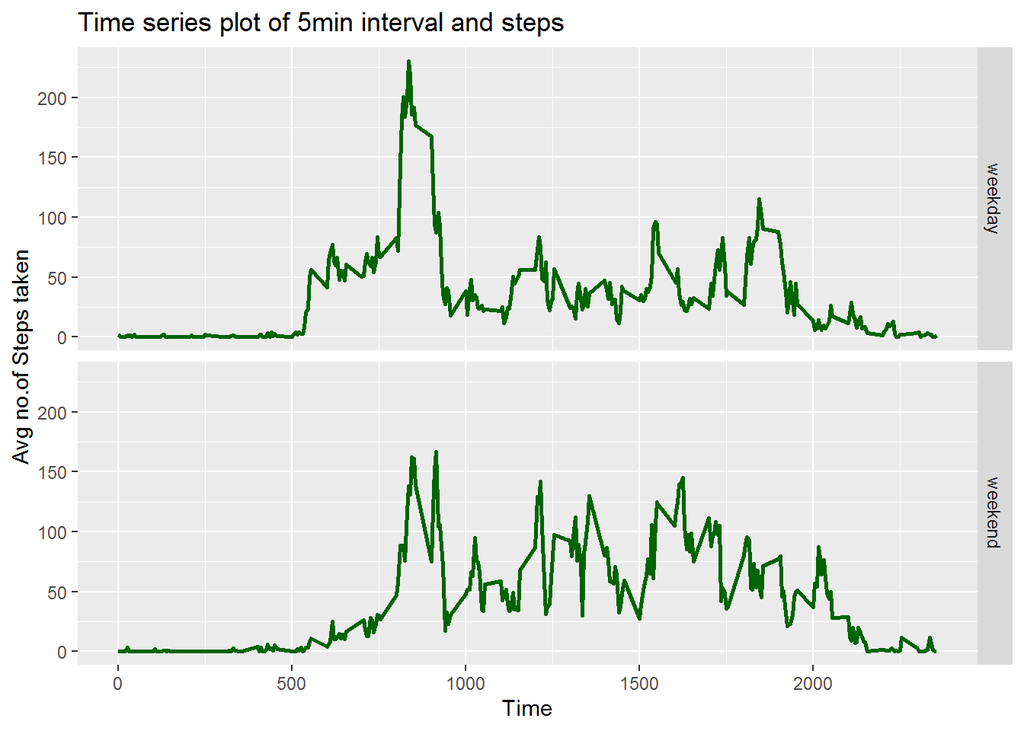

```r
#Averaging the no.of steps according to weekday and weekend days.
Weekavg <- aggregate(steps~interval+week,data=Newactivity,mean,na.rm=TRUE)
#line plot
g<-ggplot(Weekavg,aes(interval,steps))
g+geom_line(col="darkgreen",size=1)+
  ggtitle("Time series plot of 5min interval and steps")+
  xlab("Time")+
  ylab("Avg no.of Steps taken")+
  facet_grid(week~.)
```